# Explorative Data analysis

## Exloring:

### Target

- Stroke ### Socio Demographical
- Age
- Gender
- ever_married
- work_type
- Residence_type ### Clincal Conditions
- hypertension
- heart_disease
- avg_glucose_level
- bmi ### Behavioural
- smoking_status

### Metadata from Kaggle

Attribute Information 1) id: unique identifier 2) gender: "Male", "Female" or "Other" 3) age: age of the patient 4) hypertension: 0 if the patient doesn't have hypertension, 1 if the patient has hypertension 5) heart_disease: 0 if the patient doesn't have any heart diseases, 1 if the patient has a heart disease 6) ever_married: "No" or "Yes" 7) work_type: "children", "Govt_jov", "Never_worked", "Private" or "Self-employed" 8) Residence_type: "Rural" or "Urban" 9) avg_glucose_level: average glucose level in blood 10) bmi: body mass index 11) smoking_status: "formerly smoked", "never smoked", "smokes" or "Unknown"* 12) stroke: 1 if the patient had a stroke or 0 if not

### Our Calculated fields

13) bmi_imp: imputed median 14) smoking_imp: imputed modus 15) rounded_age: rounded age if original value had decimals

## Install Packages and Imports

skip this step if already installed

```python
#!pip install pandas
#!pip install seaborn
```

```python
import pandas as pd
import seaborn as sns
import matplotlib.pyplot as plt
import seaborn as sns
#
sns.set_style('whitegrid')
%matplotlib inline
```

## Read the Data

```python
df = pd.read_csv("../data/cleaned/stroke_data_cleaned.csv",low_memory = False)
```

### Basic exploration

```python
df.shape
```

```
(5110, 15)
```

```python
df.describe()
```

|  | Unnamed: 0 | age | hypertension | heart_disease | avg_glucose_level | bmi | stroke | bmi_imp | rounded_age |
| --- | --- | --- | --- | --- | --- | --- | --- | --- | --- |
| count | 5110.000000 | 5110.000000 | 5110.000000 | 5110.000000 | 5110.000000 | 4909.000000 | 5110.000000 | 5110.000000 | 5110.000000 |
| mean | 2554.500000 | 43.226614 | 0.097456 | 0.054012 | 106.147677 | 28.893237 | 0.048728 | 28.862035 | 43.215264 |
| std | 1475.274268 | 22.612647 | 0.296607 | 0.226063 | 45.283560 | 7.854067 | 0.215320 | 7.699562 | 22.633866 |
| min | 0.000000 | 0.080000 | 0.000000 | 0.000000 | 55.120000 | 10.300000 | 0.000000 | 10.300000 | 0.000000 |
| 25% | 1277.250000 | 25.000000 | 0.000000 | 0.000000 | 77.245000 | 23.500000 | 0.000000 | 23.800000 | 25.000000 |
| 50% | 2554.500000 | 45.000000 | 0.000000 | 0.000000 | 91.885000 | 28.100000 | 0.000000 | 28.100000 | 45.000000 |
| 75% | 3831.750000 | 61.000000 | 0.000000 | 0.000000 | 114.090000 | 33.100000 | 0.000000 | 32.800000 | 61.000000 |
| max | 5109.000000 | 82.000000 | 1.000000 | 1.000000 | 271.740000 | 97.600000 | 1.000000 | 97.600000 | 82.000000 |

```python
### General settings
sns.set_style('darkgrid',{'axes.grid' : False})
```

## Target Variable: Stroke

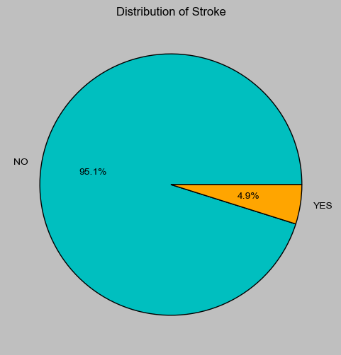

```python
plt.figure(figsize=(6, 6))
counts= df["stroke"].value_counts()
plt.style.use("grayscale")

plt.pie(counts, labels=['NO','YES'], autopct='%1.1f%%', colors=['c', 'orange'])
plt.title('Distribution of Stroke')
plt.show()
```

## Socio demographical Aspects

### Age & Gender

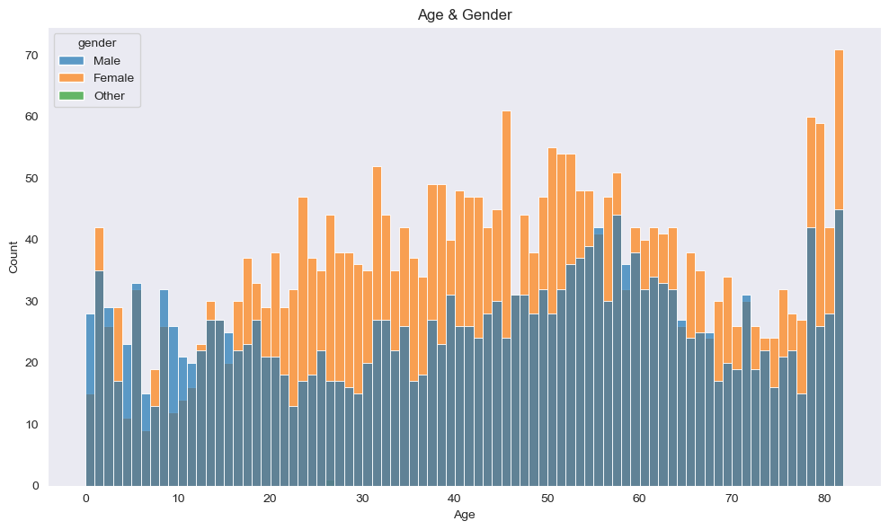

```python
plt.figure(figsize=(10, 6))
sns.histplot(data=df, x="rounded_age", hue="gender",binwidth=1, alpha=0.7)
plt.xticks(ticks=range(0, 90, 10))
plt.xlabel("Age")
plt.ylabel("Count")
plt.title('Age & Gender')
plt.tight_layout()
plt.show()
```

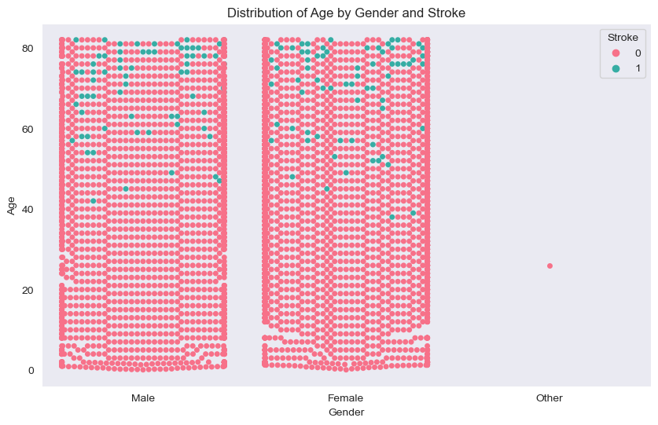

```python
plt.figure(figsize=(10, 6))
sns.swarmplot(x="gender", y="age", hue="stroke", data=df, palette="husl")
plt.title("Distribution of Age by Gender and Stroke")
plt.xlabel("Gender")
plt.ylabel("Age")
plt.legend(title="Stroke", loc="upper right")

# Show the plot
plt.show()
```

### ever_married , work_type & Residence_type

```
[Text(0.5, 1.0, 'ever married distribution')]
```

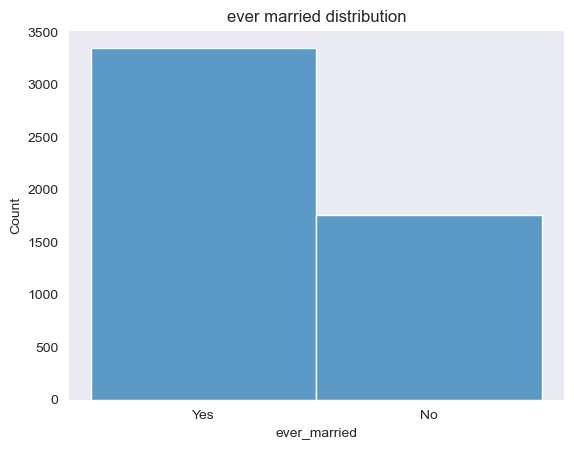

```python
sns.histplot(data=df,x="ever_married",alpha=0.7).set(title=f'ever married distribution')
```

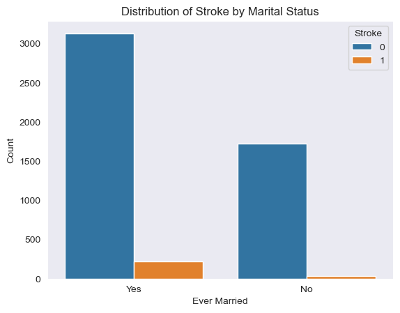

```python
sns.countplot(x="ever_married", hue="stroke", data=df)
plt.title("Distribution of Stroke by Marital Status")
plt.xlabel("Ever Married")
plt.ylabel("Count")
plt.legend(title="Stroke")

plt.show()
```

### worktype

```
[Text(0.5, 1.0, 'work_type')]
```

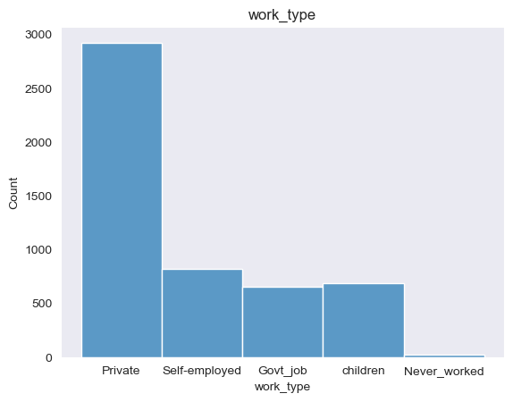

```python
sns.histplot(data=df,x="work_type",alpha=0.7).set(title=f'work_type')
```

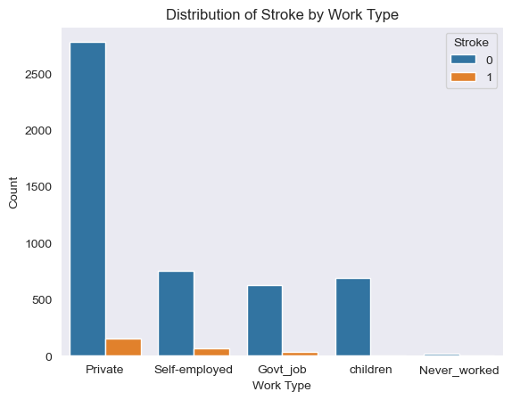

```python
sns.countplot(x="work_type", hue="stroke", data=df)
plt.title("Distribution of Stroke by Work Type")
plt.xlabel("Work Type")
plt.ylabel("Count")
plt.legend(title="Stroke")

plt.show()
```

### Residence Type

```
[Text(0.5, 1.0, 'Residence_type')]
```

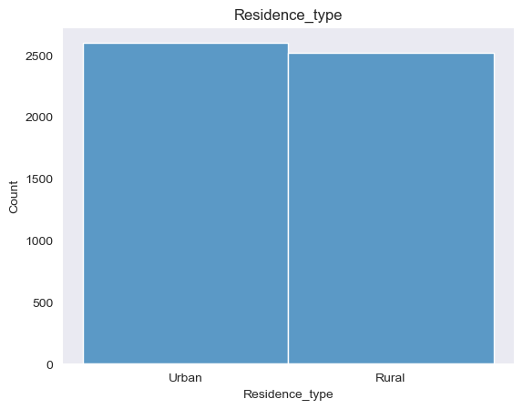

```python
sns.histplot(data=df,x="Residence_type",alpha=0.7).set(title=f'Residence_type')
```

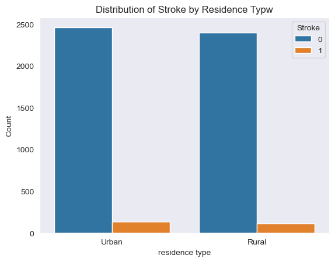

```python
sns.countplot(x="Residence_type", hue="stroke", data=df)
plt.title("Distribution of Stroke by Residence Typw")
plt.xlabel("residence type")
plt.ylabel("Count")
plt.legend(title="Stroke")

plt.show()
```

## Clinical Condition

### heart_disease

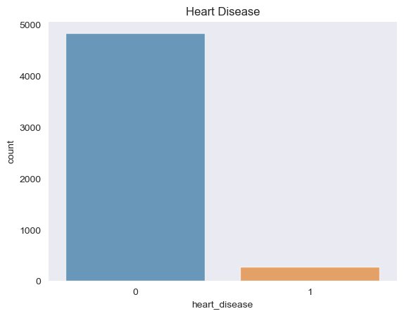

```python
sns.countplot(data=df, x="heart_disease", alpha=0.7)
plt.title("Heart Disease")
```

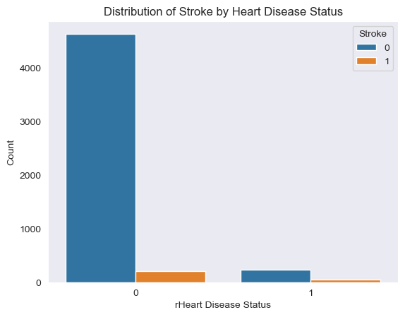

```python
sns.countplot(x="heart_disease", hue="stroke", data=df)
plt.title("Distribution of Stroke by Heart Disease Status")
plt.xlabel("rHeart Disease Status")
plt.ylabel("Count")
plt.legend(title="Stroke")

plt.show()
```

### Hypertension

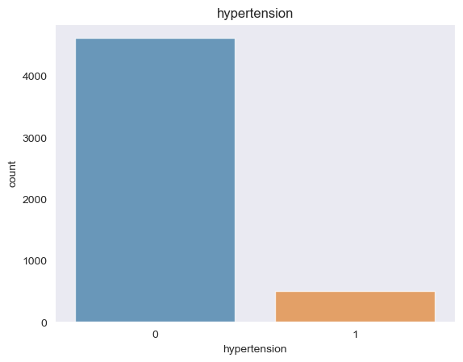

```python
sns.countplot(data=df, x="hypertension", alpha=0.7)
plt.title("hypertension")
```

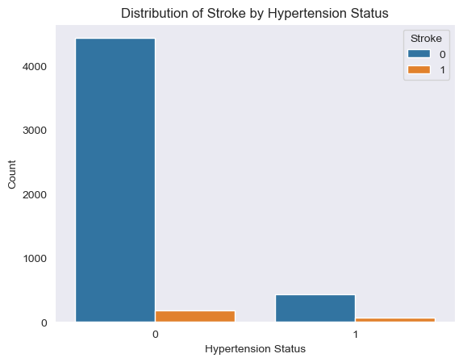

```python
sns.countplot(x="hypertension", hue="stroke", data=df)
plt.title("Distribution of Stroke by Hypertension Status")
plt.xlabel("Hypertension Status")
plt.ylabel("Count")
plt.legend(title="Stroke")

plt.show()
```

### Average Glucose level

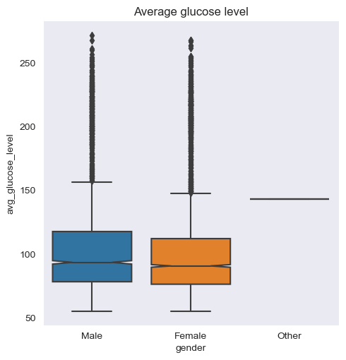

```python
sns.catplot(data=df,x="gender",y="avg_glucose_level",kind="box",
           whis=1,
           notch=True).set(title='Average glucose level')
```

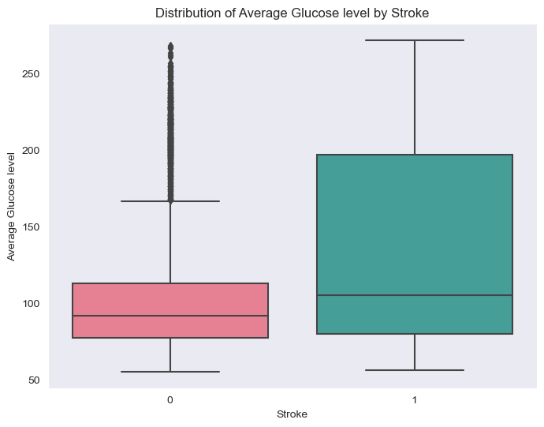

```python
plt.figure(figsize=(8, 6))
sns.boxplot(x="stroke", y="avg_glucose_level", data=df, palette="husl")
plt.title("Distribution of Average Glucose level by Stroke")
plt.xlabel("Stroke")
plt.ylabel("Average Glucose level")

# Show the plot
plt.show()
```

### Body Mass Index

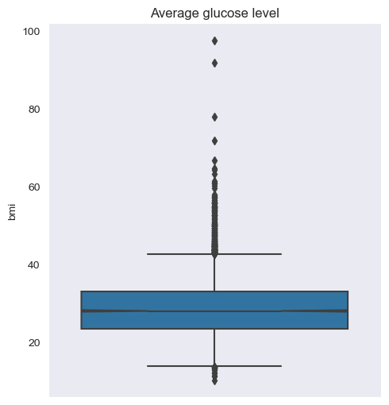

```python
sns.catplot(data=df,y="bmi",kind="box",
           whis=1,
           notch=True).set(title='Average glucose level')
```

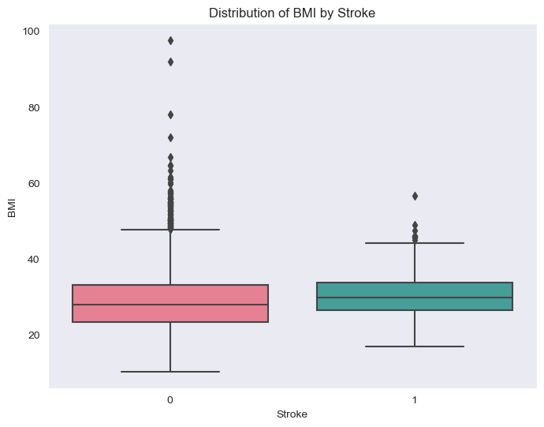

```python
plt.figure(figsize=(8, 6))
sns.boxplot(x="stroke", y="bmi", data=df, palette="husl")
plt.title("Distribution of BMI by Stroke")
plt.xlabel("Stroke")
plt.ylabel("BMI")

# Show the plot
plt.show()
```

### Behavioural

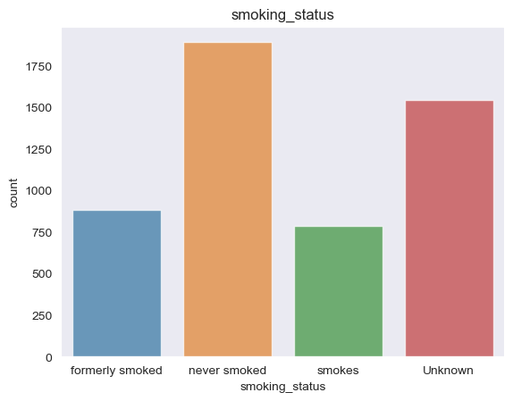

```python
sns.countplot(data=df, x="smoking_status", alpha=0.7)
plt.title("smoking_status")
```

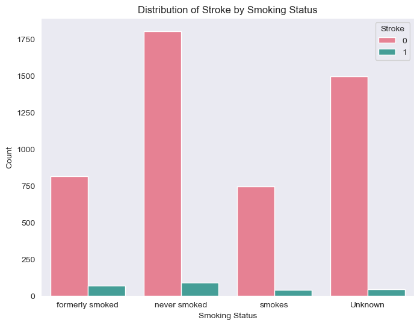

```python
plt.figure(figsize=(8, 6))
sns.countplot(x="smoking_status", hue="stroke", data=df, palette="husl")
plt.title("Distribution of Stroke by Smoking Status")
plt.xlabel("Smoking Status")
plt.ylabel("Count")
plt.legend(title="Stroke")
plt.show()
```

## Correlations

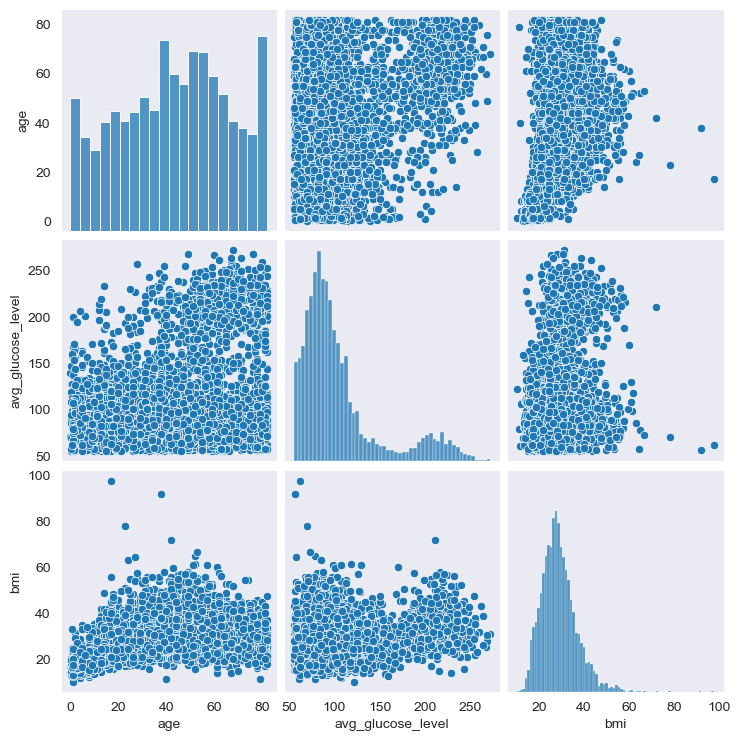

```python
sns.pairplot(df[['gender', 'age',
       'ever_married',  'avg_glucose_level',
       'bmi', 'smoking_status']])
```

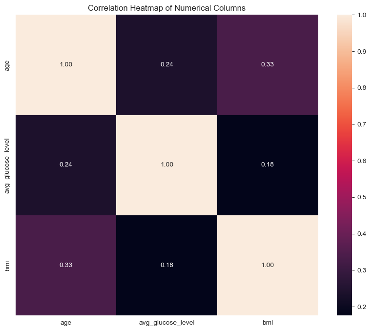

```python
numerical_cols = ['age', 'avg_glucose_level', 'bmi']
plt.figure(figsize=(10, 8))
sns.heatmap(df[numerical_cols].corr(), annot=True,  fmt='.2f')
plt.title('Correlation Heatmap of Numerical Columns')
plt.show()
```

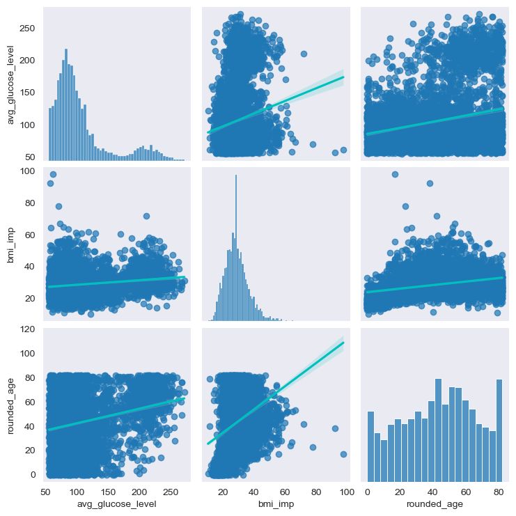

```python
sns.pairplot(df[['avg_glucose_level', 'bmi_imp', 'rounded_age']], kind='reg',
             plot_kws={'line_kws':{'color':'c'}, 'scatter_kws': {'alpha': 0.7}})
```

```python
cross_tab = pd.crosstab(df['heart_disease'], df['hypertension'])

# Display the cross-tabulation
print(cross_tab)
```

```
hypertension      0    1
heart_disease
0              4400  434
1               212   64
```

### Crosstabs

```python
pd.crosstab(df.hypertension, df.heart_disease, normalize='all')
```

| heart_disease hypertension | 0 | 1 |
| --- | --- | --- |
| 0 | 0.861057 | 0.041487 |
| 1 | 0.084932 | 0.012524 |